# Module_4_Ananya

Ananya Sharma

04/02/2022

[figure not shown]

## Introduction

- We are using the Ames Housing data set here to understand how logistic regression works.
- The binary logistic regression model does not have the limitations of linear regression model.
- The key benefit of logistic regression over other machine learning and AI implementations is that it is significantly easier to set up and train.
- When the results or contrasts represented by the data are linearly separable, it is also one of the most efficient methods.

## Create a Response variable that is greater than 200000

- Sub setting the data set, extracting values of Sale Price of homes that are greater than 2,00,000.
- Assigning value 1 if the price is greater than 2,00,000 else allocating binomial value of 0 for the purpose of performing Logistic regression.

```r
Ames_house<-Ames_house %>% mutate(House_Price=ifelse(SalePrice>200000,1,0))
```

- Training and testing the data. The test and train is usually divided into 70:30  
  ratio. It can also be divided into .75-.25 and .65-.35

## Logistic Regression

- Logistic Regression helps to determine, if the relation between the response variables and the indicator variables are statistically significant.

### Finding the Best Fit Model

```r
#1
logit.model <- glm(House_Price ~ Gr.Liv.Area + Overall.Cond + factor(Central.Air) +
                     Exterior.1st+Bldg.Type,
                   data = Ames_house, family = binomial(link = "logit"))
summary(logit.model)
```

```
Call:
glm(formula = House_Price ~ Gr.Liv.Area + Overall.Cond + factor(Central.Air) +
    Exterior.1st + Bldg.Type, family = binomial(link = "logit"),
    data = Ames_house)

Deviance Residuals:
    Min       1Q   Median       3Q      Max
-5.7235  -0.4574  -0.1685   0.2440   3.6749

Coefficients:
                       Estimate Std. Error z value Pr(>|z|)
(Intercept)          -2.359e+01  2.934e+02  -0.080  0.93592
Gr.Liv.Area           4.431e-03  1.975e-04  22.433  < 2e-16 ***
Overall.Cond         -5.109e-02  6.500e-02  -0.786  0.43188
factor(Central.Air)Y  1.748e+00  5.342e-01   3.273  0.00106 **
Exterior.1stAsphShn   3.622e+00  1.566e+03   0.002  0.99815
Exterior.1stBrkComm   1.427e+01  2.934e+02   0.049  0.96120
Exterior.1stBrkFace   1.458e+01  2.934e+02   0.050  0.96037
Exterior.1stCBlock   -1.192e+00  1.681e+03  -0.001  0.99943
Exterior.1stCemntBd   1.548e+01  2.934e+02   0.053  0.95792
Exterior.1stHdBoard   1.305e+01  2.934e+02   0.044  0.96452
Exterior.1stImStucc   3.147e+01  2.417e+03   0.013  0.98961
Exterior.1stMetalSd   1.336e+01  2.934e+02   0.046  0.96368
Exterior.1stPlywood   1.349e+01  2.934e+02   0.046  0.96334
Exterior.1stPreCast   3.204e+01  2.417e+03   0.013  0.98943
Exterior.1stStone     2.960e+01  1.383e+03   0.021  0.98292
Exterior.1stStucco    1.348e+01  2.934e+02   0.046  0.96336
Exterior.1stVinylSd   1.509e+01  2.934e+02   0.051  0.95899
Exterior.1stWd Sdng   1.289e+01  2.934e+02   0.044  0.96495
Exterior.1stWdShing   1.291e+01  2.934e+02   0.044  0.96491
Bldg.Type2fmCon      -6.003e+00  2.088e+00  -2.875  0.00405 **
Bldg.TypeDuplex      -2.838e+00  4.802e-01  -5.909 3.45e-09 ***
Bldg.TypeTwnhs       -9.760e-01  4.356e-01  -2.241  0.02504 *
Bldg.TypeTwnhsE       1.015e+00  1.906e-01   5.322 1.03e-07 ***
---
Signif. codes:  0 '***' 0.001 '**' 0.01 '*' 0.05 '.' 0.1 ' ' 1

(Dispersion parameter for binomial family taken to be 1)

    Null deviance: 3541.6  on 2929  degrees of freedom
Residual deviance: 1848.5  on 2907  degrees of freedom
AIC: 1894.5

Number of Fisher Scoring iterations: 15
```

- The AIC is around 1894.5. The AIC can be reduced further.
- Exploring fitting more variables to get a better AIC.

```r
#2

logit.model <- glm(House_Price ~ Gr.Liv.Area + Overall.Cond + factor(Central.Air) +
                     Exterior.1st+Bldg.Type + Lot.Frontage + Neighborhood,
                   data = Ames_house, family = binomial(link = "logit"))
summary(logit.model)
```

```
Call:
glm(formula = House_Price ~ Gr.Liv.Area + Overall.Cond + factor(Central.Air) +
    Exterior.1st + Bldg.Type + Lot.Frontage + Neighborhood, family = binomial(link = "logit"),
    data = Ames_house)

Deviance Residuals:
    Min       1Q   Median       3Q      Max
-5.9201  -0.2351  -0.0539   0.0500   2.9508

Coefficients:
                       Estimate Std. Error z value Pr(>|z|)
(Intercept)          -2.715e+01  1.269e+03  -0.021 0.982931
Gr.Liv.Area           4.628e-03  3.161e-04  14.642  < 2e-16 ***
Overall.Cond          3.397e-01  1.186e-01   2.865 0.004177 **
factor(Central.Air)Y  6.254e-01  7.657e-01   0.817 0.414050
Exterior.1stAsphShn   3.188e+00  6.987e+03   0.000 0.999636
Exterior.1stBrkComm   1.697e+01  1.269e+03   0.013 0.989333
Exterior.1stBrkFace   1.791e+01  1.269e+03   0.014 0.988743
Exterior.1stCBlock   -1.211e+00  6.733e+03   0.000 0.999856
Exterior.1stCemntBd   1.822e+01  1.269e+03   0.014 0.988547
Exterior.1stHdBoard   1.534e+01  1.269e+03   0.012 0.990356
Exterior.1stImStucc   3.469e+01  1.083e+04   0.003 0.997444
Exterior.1stMetalSd   1.579e+01  1.269e+03   0.012 0.990072
Exterior.1stPlywood   1.622e+01  1.269e+03   0.013 0.989801
Exterior.1stPreCast   3.878e+01  1.083e+04   0.004 0.997143
Exterior.1stStone     3.479e+01  1.083e+04   0.003 0.997437
Exterior.1stStucco    1.630e+01  1.269e+03   0.013 0.989755
Exterior.1stVinylSd   1.701e+01  1.269e+03   0.013 0.989308
Exterior.1stWd Sdng   1.567e+01  1.269e+03   0.012 0.990149
Exterior.1stWdShing   1.591e+01  1.269e+03   0.013 0.989998
Bldg.Type2fmCon      -1.557e+01  1.020e+03  -0.015 0.987823
Bldg.TypeDuplex      -1.930e+00  5.886e-01  -3.279 0.001042 **
Bldg.TypeTwnhs       -3.064e+00  7.306e-01  -4.194 2.75e-05 ***
Bldg.TypeTwnhsE      -4.281e-01  3.859e-01  -1.109 0.267303
Lot.Frontage          8.911e-03  4.334e-03   2.056 0.039799 *
NeighborhoodBlueste  -1.511e+01  3.162e+03  -0.005 0.996187
NeighborhoodBrDale   -1.453e+01  1.677e+03  -0.009 0.993085
NeighborhoodBrkSide  -1.665e+00  9.083e-01  -1.834 0.066719 .
NeighborhoodClearCr   1.944e-02  9.542e-01   0.020 0.983743
NeighborhoodCollgCr   1.187e-01  6.847e-01   0.173 0.862323
```

[output cut: 16 more lines]

```
NeighborhoodStoneBr   2.290e+00  8.698e-01   2.633 0.008457 **
NeighborhoodSWISU    -2.081e+01  1.108e+03  -0.019 0.985007
NeighborhoodTimber    8.320e-01  7.469e-01   1.114 0.265314
NeighborhoodVeenker   9.435e-01  9.974e-01   0.946 0.344157
---
Signif. codes:  0 '***' 0.001 '**' 0.01 '*' 0.05 '.' 0.1 ' ' 1

(Dispersion parameter for binomial family taken to be 1)

    Null deviance: 2915.62  on 2439  degrees of freedom
Residual deviance:  989.93  on 2391  degrees of freedom
  (490 observations deleted due to missingness)
AIC: 1087.9

Number of Fisher Scoring iterations: 18
```

```r
#3
logit.model <- glm(House_Price ~ Gr.Liv.Area + Overall.Cond + factor(Central.Air) +
                     Exterior.1st+Bldg.Type + Lot.Frontage + Neighborhood+ Year.Built+MS.Zoning,data = Ames_house, family = binomial(link = "logit"))
summary(logit.model)
```

```
Call:
glm(formula = House_Price ~ Gr.Liv.Area + Overall.Cond + factor(Central.Air) +
    Exterior.1st + Bldg.Type + Lot.Frontage + Neighborhood +
    Year.Built + MS.Zoning, family = binomial(link = "logit"),
    data = Ames_house)

Deviance Residuals:
    Min       1Q   Median       3Q      Max
-6.5122  -0.2083  -0.0430   0.0456   2.8671

Coefficients:
                       Estimate Std. Error z value Pr(>|z|)
(Intercept)          -1.536e+02  2.708e+04  -0.006  0.99548
Gr.Liv.Area           4.766e-03  3.286e-04  14.505  < 2e-16 ***
Overall.Cond          7.472e-01  1.433e-01   5.214 1.85e-07 ***
factor(Central.Air)Y -6.298e-01  8.794e-01  -0.716  0.47389
Exterior.1stAsphShn   1.185e+00  6.767e+03   0.000  0.99986
Exterior.1stBrkComm   1.509e+01  1.282e+03   0.012  0.99061
Exterior.1stBrkFace   1.711e+01  1.282e+03   0.013  0.98936
Exterior.1stCBlock    1.943e-01  2.708e+04   0.000  0.99999
Exterior.1stCemntBd   1.599e+01  1.282e+03   0.012  0.99005
Exterior.1stHdBoard   1.427e+01  1.282e+03   0.011  0.99112
Exterior.1stImStucc   3.343e+01  1.083e+04   0.003  0.99754
Exterior.1stMetalSd   1.473e+01  1.282e+03   0.011  0.99083
Exterior.1stPlywood   1.517e+01  1.282e+03   0.012  0.99056
Exterior.1stPreCast   3.914e+01  1.083e+04   0.004  0.99712
Exterior.1stStone     3.299e+01  1.083e+04   0.003  0.99757
Exterior.1stStucco    1.632e+01  1.282e+03   0.013  0.98985
Exterior.1stVinylSd   1.522e+01  1.282e+03   0.012  0.99053
Exterior.1stWd Sdng   1.517e+01  1.282e+03   0.012  0.99056
Exterior.1stWdShing   1.510e+01  1.282e+03   0.012  0.99060
Bldg.Type2fmCon      -1.505e+01  1.032e+03  -0.015  0.98836
Bldg.TypeDuplex      -1.549e+00  5.992e-01  -2.585  0.00974 **
Bldg.TypeTwnhs       -3.093e+00  7.463e-01  -4.145 3.40e-05 ***
Bldg.TypeTwnhsE      -7.790e-01  4.389e-01  -1.775  0.07593 .
Lot.Frontage          8.654e-03  4.632e-03   1.868  0.06172 .
NeighborhoodBlueste  -1.474e+01  3.191e+03  -0.005  0.99631
NeighborhoodBrDale   -1.327e+01  1.696e+03  -0.008  0.99376
NeighborhoodBrkSide   1.046e+00  1.211e+00   0.864  0.38773
NeighborhoodClearCr   9.053e-01  1.032e+00   0.877  0.38046
```

[output cut: 24 more lines]

```
MS.ZoningI (all)     -9.844e+00  2.914e+04   0.000  0.99973
MS.ZoningRH          -1.662e+01  2.713e+04  -0.001  0.99951
MS.ZoningRL          -2.173e-01  2.708e+04   0.000  0.99999
MS.ZoningRM          -9.964e-02  2.708e+04   0.000  1.00000
---
Signif. codes:  0 '***' 0.001 '**' 0.01 '*' 0.05 '.' 0.1 ' ' 1

(Dispersion parameter for binomial family taken to be 1)

    Null deviance: 2915.62  on 2439  degrees of freedom
Residual deviance:  930.23  on 2384  degrees of freedom
  (490 observations deleted due to missingness)
AIC: 1042.2

Number of Fisher Scoring iterations: 18
```

### Optimized Model

- A few exterior features variable are the Neighborhood, Fence,Exterior Condition, Exterior Quality, Mansion Veneer Area, Over all quality of the house etc.
- A few features that define the interior features of the house are Fireplace, Basement Quality,Basement Finish, Kitchen Quality etc.
- A few features defining the Location features of a house are Lot Area, Lot Frontage, Sub Class etc.

```r
#5

logit.model <- glm(House_Price ~ Gr.Liv.Area+Year.Built+Fireplaces+Garage.Area+
                     Bsmt.Qual+BsmtFin.SF.1+ Lot.Area+ Street+ factor(Kitchen.Qual)+                      Sale.Condition+ House.Style+Exter.Cond+MS.SubClass+Fence+
                    factor(Exter.Qual)+Exterior.1st+Neighborhood+Full.Bath+
                     Lot.Frontage+Mas.Vnr.Area+Overall.Cond+ Overall.Qual,
                   data = Ames_house, family = binomial(link = "logit"))
summary(logit.model)
```

```
Call:
glm(formula = House_Price ~ Gr.Liv.Area + Year.Built + Fireplaces +
    Garage.Area + Bsmt.Qual + BsmtFin.SF.1 + Lot.Area + Street +
    factor(Kitchen.Qual) + Sale.Condition + House.Style + Exter.Cond +
    MS.SubClass + Fence + factor(Exter.Qual) + Exterior.1st +
    Neighborhood + Full.Bath + Lot.Frontage + Mas.Vnr.Area +
    Overall.Cond + Overall.Qual, family = binomial(link = "logit"),
    data = Ames_house)

Deviance Residuals:
       Min          1Q      Median          3Q         Max
-5.545e-05  -2.100e-08  -2.100e-08  -2.100e-08   6.717e-05

Coefficients:
                         Estimate Std. Error z value Pr(>|z|)
(Intercept)            -3.349e+03  3.416e+06  -0.001    0.999
Gr.Liv.Area             7.779e-02  6.424e+01   0.001    0.999
Year.Built              1.455e+00  1.708e+03   0.001    0.999
Fireplaces              1.668e+01  3.308e+04   0.001    1.000
Garage.Area            -1.624e-02  1.603e+02   0.000    1.000
Bsmt.QualFa             1.391e+01  2.446e+05   0.000    1.000
Bsmt.QualGd            -1.765e+01  2.341e+05   0.000    1.000
Bsmt.QualTA            -1.555e+01  2.407e+05   0.000    1.000
BsmtFin.SF.1            4.693e-02  8.928e+01   0.001    1.000
Lot.Area                5.516e-03  4.234e+00   0.001    0.999
StreetPave             -6.407e+01  6.914e+05   0.000    1.000
factor(Kitchen.Qual)Fa  1.255e+01  2.511e+05   0.000    1.000
factor(Kitchen.Qual)Gd  1.134e+01  1.569e+05   0.000    1.000
factor(Kitchen.Qual)TA -5.906e+00  1.516e+05   0.000    1.000
Sale.ConditionAdjLand   1.897e+02  2.693e+05   0.001    0.999
Sale.ConditionAlloca    2.048e+01  5.116e+05   0.000    1.000
Sale.ConditionFamily   -5.688e+01  1.726e+05   0.000    1.000
Sale.ConditionNormal    9.326e+00  1.165e+05   0.000    1.000
Sale.ConditionPartial   5.051e+01  2.910e+05   0.000    1.000
House.Style1.5Unf       3.882e+01  1.921e+05   0.000    1.000
House.Style1Story      -1.194e+01  6.961e+04   0.000    1.000
House.Style2.5Fin      -4.153e+01  4.745e+07   0.000    1.000
House.Style2.5Unf      -3.720e+01  1.676e+05   0.000    1.000
House.Style2Story      -8.536e+00  6.868e+04   0.000    1.000
House.StyleSFoyer       1.526e+01  1.906e+05   0.000    1.000
```

[output cut: 43 more lines]

```
NeighborhoodVeenker    -4.805e+01  3.952e+05   0.000    1.000
Full.Bath               2.055e+01  4.637e+04   0.000    1.000
Lot.Frontage           -9.508e-02  1.591e+03   0.000    1.000
Mas.Vnr.Area            2.030e-02  1.315e+02   0.000    1.000
Overall.Cond            2.709e+01  1.777e+04   0.002    0.999
Overall.Qual            1.241e+01  2.717e+04   0.000    1.000

(Dispersion parameter for binomial family taken to be 1)

    Null deviance: 2.9039e+02  on 460  degrees of freedom
Residual deviance: 3.7962e-08  on 387  degrees of freedom
  (2469 observations deleted due to missingness)
AIC: 148

Number of Fisher Scoring iterations: 25
```

### Understand ROC and Area Under the Curve

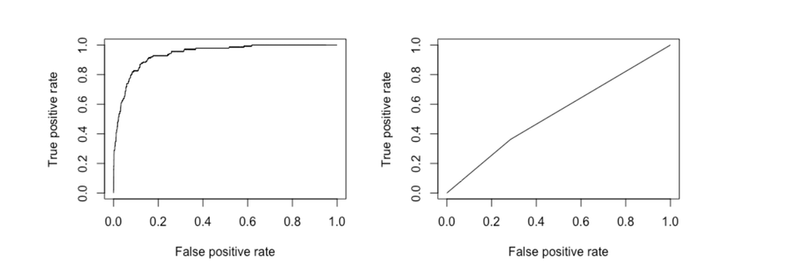

Area Under the curve

- AUC ranges from 0.9-1.00 are considered Excellent.
- The first graph is a good model, whereas the second model is a poor classifying model.

## Train and Test the Data

```r
trainIndex <-createDataPartition(Ames_house$House_Price, p=0.70, list = FALSE)
train <- Ames_house[trainIndex,]
test <- Ames_house[-trainIndex,]

#1 House Price and Mason Veneer Area(Exterior Feature)
model1 <- glm(House_Price  ~ Mas.Vnr.Area, data = train, family = binomial(link = "logit"))
summary(model1)
```

```
Call:
glm(formula = House_Price ~ Mas.Vnr.Area, family = binomial(link = "logit"),
    data = train)

Deviance Residuals:
    Min       1Q   Median       3Q      Max
-2.9845  -0.6605  -0.6605   0.9258   1.8055

Coefficients:
               Estimate Std. Error z value Pr(>|z|)
(Intercept)  -1.4117639  0.0641687  -22.00   <2e-16 ***
Mas.Vnr.Area  0.0047824  0.0003324   14.39   <2e-16 ***
---
Signif. codes:  0 '***' 0.001 '**' 0.01 '*' 0.05 '.' 0.1 ' ' 1

(Dispersion parameter for binomial family taken to be 1)

    Null deviance: 2476.5  on 2036  degrees of freedom
Residual deviance: 2200.0  on 2035  degrees of freedom
  (14 observations deleted due to missingness)
AIC: 2204

Number of Fisher Scoring iterations: 4
```

```r
coef(model1)
```

```
 (Intercept) Mas.Vnr.Area
-1.411763892  0.004782355
```

```r
exp(coef(model1))
```

```
 (Intercept) Mas.Vnr.Area
    0.243713     1.004794
```

```r
probablilities.train <-predict(model1, newdata = train, type = "response")
predicted.classes.min <- as.factor(ifelse(probablilities.train > 0.5,1,0))


probablilities.test <-predict(model1, newdata = test, type = "response")
predicted.classes.min <- as.factor(ifelse(probablilities.test > 0.5,"Yes","No"))

ROC1 <- roc(test$House_Price, probablilities.test)
```

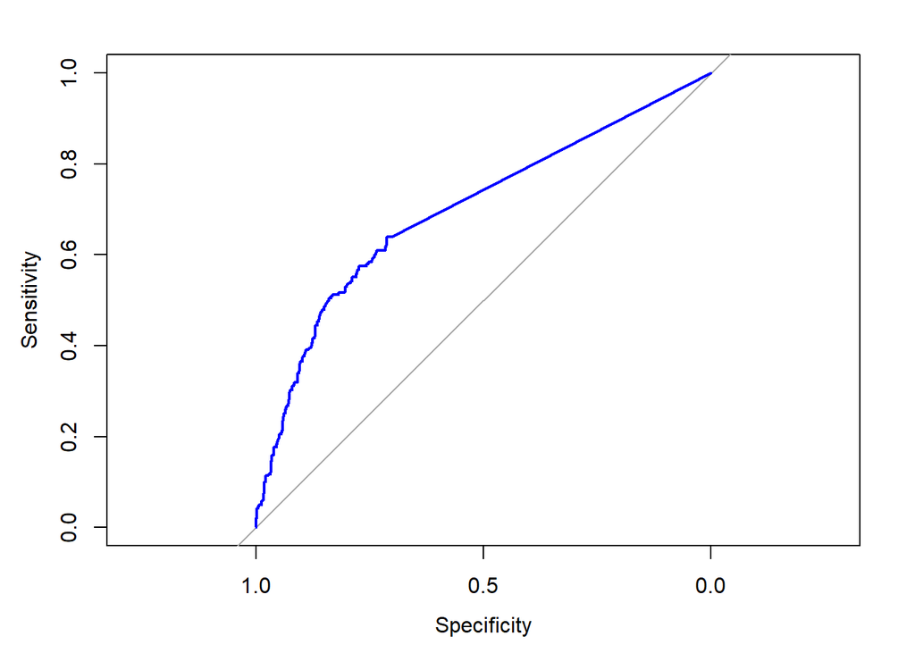

```r
plot(ROC1, col= "blue", ylab="Sensitivity", xlab = "Specificity") #plot the graph
```

```r
auc <- auc(ROC1)
auc
```

```
Area under the curve: 0.699
```

```r
pred_logodds <- predict(model1, test)

pred_odds <- exp(pred_logodds)

probs <- pred_odds/(1+pred_odds)

pred_probs <- predict(model1, test, type = 'response')

#2 House Price and Fence( Exterior Feature)

model2 <- glm(House_Price~ Fence, data = train, family = binomial(link = "logit"))
summary(model2)
```

```
Call:
glm(formula = House_Price ~ Fence, family = binomial(link = "logit"),
    data = train)

Deviance Residuals:
    Min       1Q   Median       3Q      Max
-0.7478  -0.4289  -0.4289  -0.3975   2.2706

Coefficients:
            Estimate Std. Error z value Pr(>|z|)
(Intercept)  -1.1314     0.2572  -4.400 1.08e-05 ***
FenceGdWo    -1.3673     0.4965  -2.754 0.005888 **
FenceMnPrv   -1.2086     0.3440  -3.513 0.000443 ***
FenceMnWw   -15.4347   799.8483  -0.019 0.984604
---
Signif. codes:  0 '***' 0.001 '**' 0.01 '*' 0.05 '.' 0.1 ' ' 1

(Dispersion parameter for binomial family taken to be 1)

    Null deviance: 291.75  on 408  degrees of freedom
Residual deviance: 275.81  on 405  degrees of freedom
  (1642 observations deleted due to missingness)
AIC: 283.81

Number of Fisher Scoring iterations: 15
```

```r
coef(model2)
```

```
(Intercept)   FenceGdWo  FenceMnPrv   FenceMnWw
  -1.131402   -1.367298   -1.208571  -15.434666
```

```r
exp(coef(model2))
```

```
 (Intercept)    FenceGdWo   FenceMnPrv    FenceMnWw
3.225806e-01 2.547945e-01 2.986239e-01 1.980658e-07
```

```r
#summary(train$House_Price)

probablilities.train <-predict(model2, newdata = train, type = "response")
predicted.classes.min <- as.factor(ifelse(probablilities.train > 0.5,1,0))


probablilities.test <-predict(model2, newdata = test, type = "response")
predicted.classes.min <- as.factor(ifelse(probablilities.test > 0.5,"Yes","No"))


ROC2 <- roc(test$House_Price, probablilities.test)
```

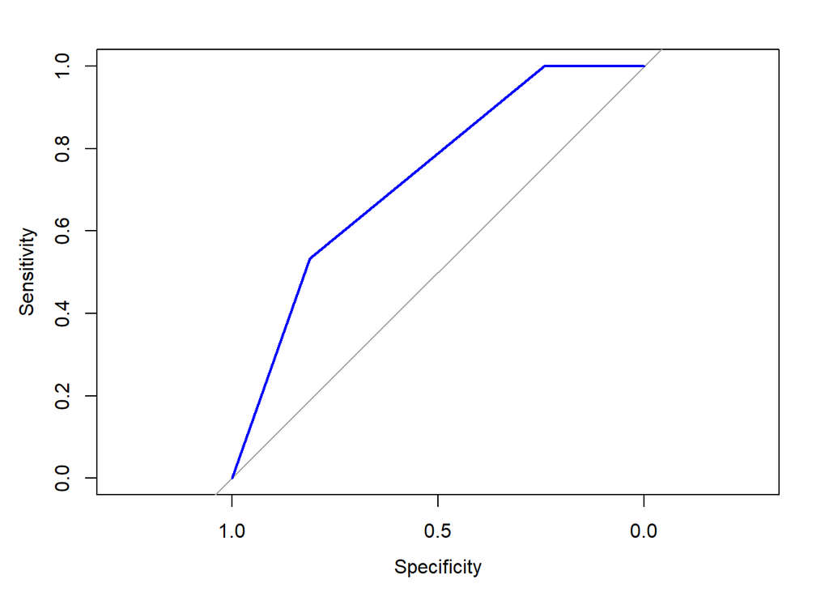

```r
plot(ROC2, col= "blue", ylab="Sensitivity", xlab = "Specificity")
```

```r
auc <- auc(ROC2)
auc
```

```
Area under the curve: 0.7288
```

```r
pred_logodds <- predict(model2, test)

pred_odds <- exp(pred_logodds)

probs <- pred_odds/(1+pred_odds)

pred_probs <- predict(model2, test, type = 'response')

#3 House Price and Kitchen ( interior Feature)

model3 <- glm(House_Price~Kitchen.Qual , data = train, family = binomial(link = "logit"))
summary(model3)
```

```
Call:
glm(formula = House_Price ~ Kitchen.Qual, family = binomial(link = "logit"),
    data = train)

Deviance Residuals:
    Min       1Q   Median       3Q      Max
-2.1125  -0.3762  -0.3762   0.4767   2.5128

Coefficients:
               Estimate Std. Error z value Pr(>|z|)
(Intercept)      2.1178     0.2646   8.003 1.21e-15 ***
Kitchen.QualFa  -5.2313     0.7696  -6.798 1.06e-11 ***
Kitchen.QualGd  -2.1104     0.2737  -7.710 1.26e-14 ***
Kitchen.QualPo -14.6838   324.7438  -0.045    0.964
Kitchen.QualTA  -4.7303     0.2918 -16.212  < 2e-16 ***
---
Signif. codes:  0 '***' 0.001 '**' 0.01 '*' 0.05 '.' 0.1 ' ' 1

(Dispersion parameter for binomial family taken to be 1)

    Null deviance: 2505.3  on 2050  degrees of freedom
Residual deviance: 1766.0  on 2046  degrees of freedom
AIC: 1776

Number of Fisher Scoring iterations: 11
```

```r
coef(model3)
```

```
   (Intercept) Kitchen.QualFa Kitchen.QualGd Kitchen.QualPo Kitchen.QualTA
      2.117760      -5.231276      -2.110398     -14.683823      -4.730313
```

```r
exp(coef(model3))
```

```
   (Intercept) Kitchen.QualFa Kitchen.QualGd Kitchen.QualPo Kitchen.QualTA
  8.312500e+00   5.346700e-03   1.211897e-01   4.196590e-07   8.823712e-03
```

```r
#summary(train$House_Price)

probablilities.train <-predict(model3, newdata = train, type = "response")
predicted.classes.min <- as.factor(ifelse(probablilities.train > 0.5,1,0))


probablilities.test <-predict(model3, newdata = test, type = "response")
predicted.classes.min <- as.factor(ifelse(probablilities.test > 0.5,"Yes","No"))


ROC3 <- roc(test$House_Price, probablilities.test)
```

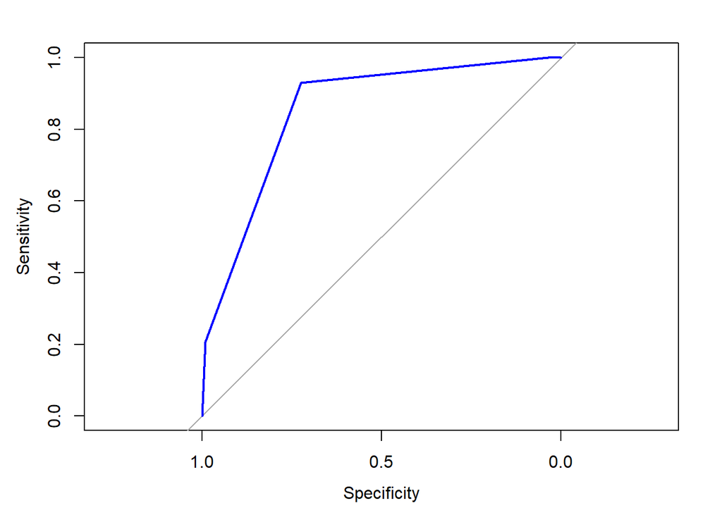

```r
plot(ROC3, col= "blue", ylab="Sensitivity", xlab = "Specificity")
```

```r
auc <- auc(ROC3)
auc
```

```
Area under the curve: 0.8522
```

```r
pred_logodds <- predict(model3, test)

pred_odds <- exp(pred_logodds)

probs <- pred_odds/(1+pred_odds)

pred_probs <- predict(model3, test, type = 'response')

#4 House Price and Full Bath

model4 <- glm(House_Price~Full.Bath , data = train, family = binomial(link = "logit"))
summary(model4)   # Summarised model expansion
```

```
Call:
glm(formula = House_Price ~ Full.Bath, family = binomial(link = "logit"),
    data = train)

Deviance Residuals:
    Min       1Q   Median       3Q      Max
-2.2185  -1.1281  -0.3775   1.2275   3.1939

Coefficients:
            Estimate Std. Error z value Pr(>|z|)
(Intercept)  -5.0945     0.2551  -19.97   <2e-16 ***
Full.Bath     2.4887     0.1360   18.30   <2e-16 ***
---
Signif. codes:  0 '***' 0.001 '**' 0.01 '*' 0.05 '.' 0.1 ' ' 1

(Dispersion parameter for binomial family taken to be 1)

    Null deviance: 2505.3  on 2050  degrees of freedom
Residual deviance: 1970.1  on 2049  degrees of freedom
AIC: 1974.1

Number of Fisher Scoring iterations: 5
```

```r
coef(model4)
```

```
(Intercept)   Full.Bath
  -5.094468    2.488720
```

```r
exp(coef(model4))
```

```
 (Intercept)    Full.Bath
 0.006130567 12.045846550
```

```r
#summary(train$House_Price)

probablilities.train <-predict(model4, newdata = train, type = "response")
predicted.classes.min <- as.factor(ifelse(probablilities.train > 0.5,1,0))


probablilities.test <-predict(model4, newdata = test, type = "response")
predicted.classes.min <- as.factor(ifelse(probablilities.test > 0.5,"Yes","No"))


ROC4 <- roc(test$House_Price, probablilities.test)
```

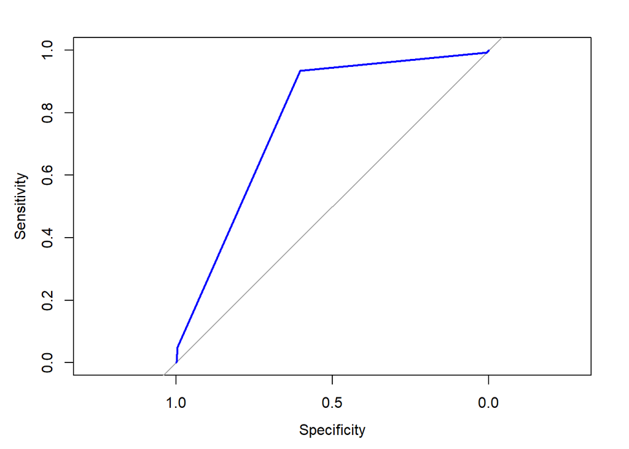

```r
plot(ROC4, col= "blue",ylab="Sensitivity", xlab = "Specificity")
```

```r
auc <- auc(ROC4)
auc
```

```
Area under the curve: 0.7737
```

```r
pred_logodds <- predict(model4, test)

pred_odds <- exp(pred_logodds)

probs <- pred_odds/(1+pred_odds)

pred_probs <- predict(model4, test, type = 'response')

#5 House Price and Location

model5 <- glm(House_Price~ Neighborhood , data = train, family = binomial(link = "logit"))
summary(model5)   # Summarised model expansion
```

```
Call:
glm(formula = House_Price ~ Neighborhood, family = binomial(link = "logit"),
    data = train)

Deviance Residuals:
    Min       1Q   Median       3Q      Max
-2.2218  -0.6400  -0.2504   0.4208   3.0631

Coefficients:
                     Estimate Std. Error z value Pr(>|z|)
(Intercept)           -0.3185     0.4647  -0.685 0.493125
NeighborhoodBlueste  -17.2476  1615.1039  -0.011 0.991480
NeighborhoodBrDale   -17.2476   807.5521  -0.021 0.982960
NeighborhoodBrkSide   -2.1802     0.6295  -3.463 0.000533 ***
NeighborhoodClearCr    0.3185     0.5839   0.545 0.585468
NeighborhoodCollgCr    0.3803     0.4864   0.782 0.434221
NeighborhoodCrawfor    0.4726     0.5271   0.897 0.369908
NeighborhoodEdwards   -2.4619     0.5905  -4.169 3.05e-05 ***
NeighborhoodGilbert   -1.0165     0.5162  -1.969 0.048908 *
NeighborhoodGreens     1.0116     1.3099   0.772 0.439962
NeighborhoodGrnHill   17.8845  2797.4420   0.006 0.994899
NeighborhoodIDOTRR    -3.7924     1.1101  -3.416 0.000635 ***
NeighborhoodLandmrk  -17.2476  3956.1804  -0.004 0.996522
NeighborhoodMeadowV  -17.2476   791.2362  -0.022 0.982609
NeighborhoodMitchel   -1.1632     0.5456  -2.132 0.033031 *
NeighborhoodNAmes     -2.5544     0.5310  -4.811 1.50e-06 ***
NeighborhoodNoRidge   17.8845   543.4234   0.033 0.973746
NeighborhoodNPkVill  -17.2476  1021.4815  -0.017 0.986528
NeighborhoodNridgHt    2.6980     0.5702   4.731 2.23e-06 ***
NeighborhoodNWAmes    -0.7049     0.5244  -1.344 0.178875
NeighborhoodOldTown   -3.1284     0.6498  -4.814 1.48e-06 ***
NeighborhoodSawyer    -4.3637     1.1069  -3.942 8.07e-05 ***
NeighborhoodSawyerW   -0.4064     0.5136  -0.791 0.428741
NeighborhoodSomerst    1.0459     0.5004   2.090 0.036608 *
NeighborhoodStoneBr    1.8940     0.6458   2.933 0.003359 **
NeighborhoodSWISU    -17.2476   659.3636  -0.026 0.979131
NeighborhoodTimber     1.0761     0.5602   1.921 0.054733 .
NeighborhoodVeenker    1.5224     0.8058   1.889 0.058833 .
---
Signif. codes:  0 '***' 0.001 '**' 0.01 '*' 0.05 '.' 0.1 ' ' 1

(Dispersion parameter for binomial family taken to be 1)

    Null deviance: 2505.3  on 2050  degrees of freedom
Residual deviance: 1488.0  on 2023  degrees of freedom
AIC: 1544

Number of Fisher Scoring iterations: 16
```

```r
coef(model5)
```

```
        (Intercept) NeighborhoodBlueste  NeighborhoodBrDale NeighborhoodBrkSide
         -0.3184537         -17.2476148         -17.2476148          -2.1802462
NeighborhoodClearCr NeighborhoodCollgCr NeighborhoodCrawfor NeighborhoodEdwards
          0.3184537           0.3803291           0.4726044          -2.4619171
NeighborhoodGilbert  NeighborhoodGreens NeighborhoodGrnHill  NeighborhoodIDOTRR
         -1.0165473           1.0116009          17.8845222          -3.7924201
NeighborhoodLandmrk NeighborhoodMeadowV NeighborhoodMitchel   NeighborhoodNAmes
        -17.2476148         -17.2476148          -1.1631508          -2.5544044
NeighborhoodNoRidge NeighborhoodNPkVill NeighborhoodNridgHt  NeighborhoodNWAmes
         17.8845222         -17.2476148           2.6979999          -0.7049351
NeighborhoodOldTown  NeighborhoodSawyer NeighborhoodSawyerW NeighborhoodSomerst
         -3.1283542          -4.3636775          -0.4064421           1.0458900
NeighborhoodStoneBr   NeighborhoodSWISU  NeighborhoodTimber NeighborhoodVeenker
          1.8939901         -17.2476148           1.0761394           1.5224265
```

```r
exp(coef(model5))
```

```
        (Intercept) NeighborhoodBlueste  NeighborhoodBrDale NeighborhoodBrkSide
       7.272727e-01        3.231886e-08        3.231886e-08        1.130137e-01
NeighborhoodClearCr NeighborhoodCollgCr NeighborhoodCrawfor NeighborhoodEdwards
       1.375000e+00        1.462766e+00        1.604167e+00        8.527132e-02
NeighborhoodGilbert  NeighborhoodGreens NeighborhoodGrnHill  NeighborhoodIDOTRR
       3.618421e-01        2.750000e+00        5.849912e+07        2.254098e-02
NeighborhoodLandmrk NeighborhoodMeadowV NeighborhoodMitchel   NeighborhoodNAmes
       3.231886e-08        3.231886e-08        3.125000e-01        7.773852e-02
NeighborhoodNoRidge NeighborhoodNPkVill NeighborhoodNridgHt  NeighborhoodNWAmes
       5.849912e+07        3.231886e-08        1.485000e+01        4.941406e-01
NeighborhoodOldTown  NeighborhoodSawyer NeighborhoodSawyerW NeighborhoodSomerst
       4.378981e-02        1.273148e-02        6.660156e-01        2.845930e+00
NeighborhoodStoneBr   NeighborhoodSWISU  NeighborhoodTimber NeighborhoodVeenker
       6.645833e+00        3.231886e-08        2.933333e+00        4.583333e+00
```

```r
summary(train$House_Price)
```

```
   Min. 1st Qu.  Median    Mean 3rd Qu.    Max.
 0.0000  0.0000  0.0000  0.2999  1.0000  1.0000
```

```r
probablilities.train <-predict(model5, newdata = train, type = "response")
predicted.classes.min <- as.factor(ifelse(probablilities.train > 0.5,1,0))

probablilities.test <-predict(model5, newdata = test, type = "response")
predicted.classes.min <- as.factor(ifelse(probablilities.test > 0.5,"Yes","No"))


ROC5 <- roc(test$House_Price, probablilities.test)
```

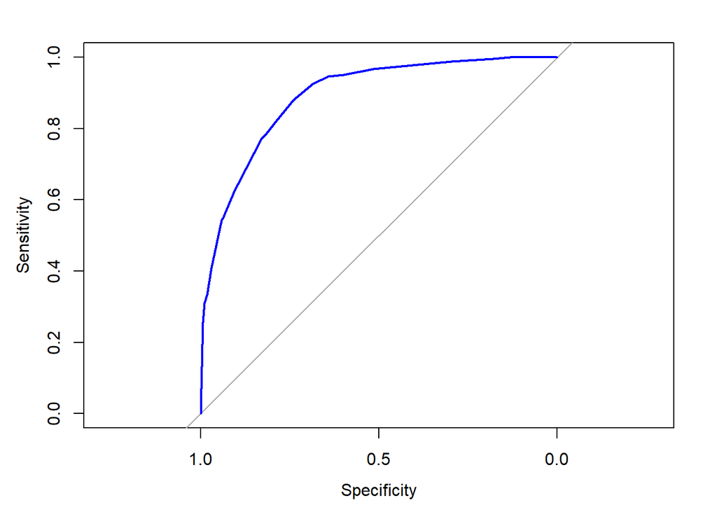

```r
plot(ROC5, col= "blue", ylab="Sensitivity", xlab = "Specificity")
```

```r
auc <- auc(ROC5)
auc
```

```
Area under the curve: 0.8904
```

```r
pred_logodds <- predict(model5, test)

pred_odds <- exp(pred_logodds)

probs <- pred_odds/(1+pred_odds)

pred_probs <- predict(model5, test, type = 'response')


#6

model6 <- glm(House_Price~ Year.Built , data = train, family = binomial(link = "logit"))
summary(model6)   # Summarised model expansion
```

```
Call:
glm(formula = House_Price ~ Year.Built, family = binomial(link = "logit"),
    data = train)

Deviance Residuals:
    Min       1Q   Median       3Q      Max
-1.4776  -0.6822  -0.3792   0.9665   3.5689

Coefficients:
              Estimate Std. Error z value Pr(>|z|)
(Intercept) -1.091e+02  5.702e+00  -19.13   <2e-16 ***
Year.Built   5.465e-02  2.868e-03   19.05   <2e-16 ***
---
Signif. codes:  0 '***' 0.001 '**' 0.01 '*' 0.05 '.' 0.1 ' ' 1

(Dispersion parameter for binomial family taken to be 1)

    Null deviance: 2505.3  on 2050  degrees of freedom
Residual deviance: 1905.8  on 2049  degrees of freedom
AIC: 1909.8

Number of Fisher Scoring iterations: 5
```

```r
coef(model6)
```

```
  (Intercept)    Year.Built
-109.10473538    0.05464775
```

```r
exp(coef(model6))
```

```
 (Intercept)   Year.Built
4.134428e-48 1.056169e+00
```

```r
probablilities.train <-predict(model6, newdata = train, type = "response")
predicted.classes.min <- as.factor(ifelse(probablilities.train > 0.5,1,0))

probablilities.test <-predict(model6, newdata = test, type = "response")
predicted.classes.min <- as.factor(ifelse(probablilities.test > 0.5,"Yes","No"))


ROC6 <- roc(test$House_Price, probablilities.test)
```

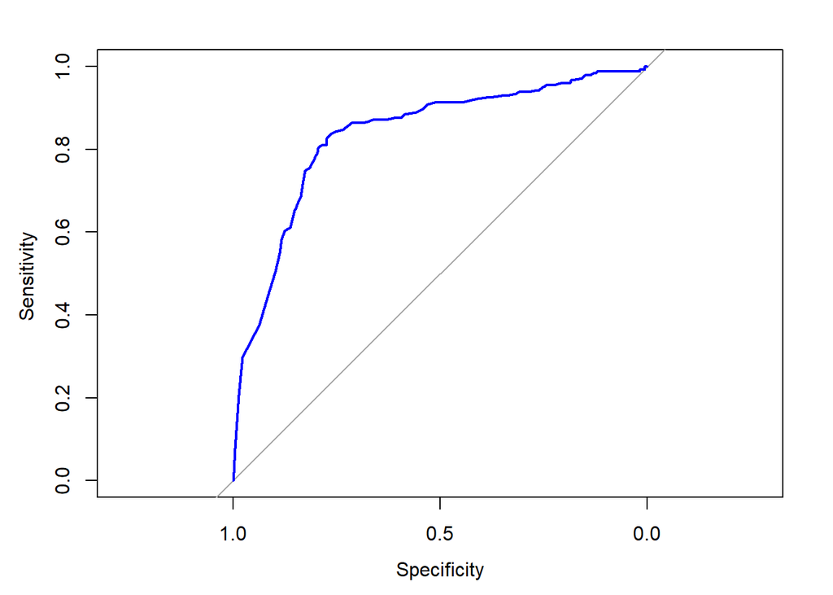

```r
plot(ROC6, col= "blue", ylab="Sensitivity ", xlab ="Specificity")
```

```r
auc <- auc(ROC6)
auc
```

```
Area under the curve: 0.8353
```

```r
pred_logodds <- predict(model6, test)

pred_odds <- exp(pred_logodds)

probs <- pred_odds/(1+pred_odds)

pred_probs <- predict(model6, test, type = 'response')
```

## Computing Odds Ratio

```r
OddsRatio(table(Ames_house$Central.Air,Ames_house$House_Price))
```

```
[1] 14.31138
```

```r
OddsRatio(table(Ames_house$Street,Ames_house$House_Price))
```

```
[1] 4.56644
```

```r
assocstats(table(Ames_house$Year.Remod.Add, Ames_house$House_Price))
```

```
                   X^2 df P(> X^2)
Likelihood Ratio 878.0 60        0
Pearson          765.1 60        0

Phi-Coefficient   : NA
Contingency Coeff.: 0.455
Cramer's V        : 0.511
```

```r
assocstats(table(Ames_house$Neighborhood,Ames_house$House_Price))
```

```
                    X^2 df P(> X^2)
Likelihood Ratio 1421.2 27        0
Pearson          1288.5 27        0

Phi-Coefficient   : NA
Contingency Coeff.: 0.553
Cramer's V        : 0.663
```

- The Cramer’s V shows that Year of Remake of the house has a strong affect on the Sale Price of the house.
- The Neighborhood is a strong factor that affects the sale Price of house.

## Summary

- In Logistic Regression, the response variables in logit models are log based. Hence, we have to take their exponent so as to convert them back to probability ratios.
- ROC Curve and Area under the curve plot is used to find out the performance for a binary classifier. A good predictor variable must be drawn closer to one.
- Mason Veneer Area is not a very strong predictor variable, the area under the curve holds a very less value.
- Kitchen Quality and Neighborhood are strong Predictor variables.
- Year the house was built and the Full Bath are moderate predictors towards deciding the best fit model and deriving a dependent response variable.

## Reference:

- Interpretation of R’s output for binomial regression. (2014, February 12). Cross Validated.https://stats.stackexchange.com/questions/86351/interpretation-of-rs-outp ut-for-binomial-regression
- LaBarr, D. (2021, September). Logistic Regression. Https://Www.Ariclabarr.Com/. Retrieved February 7, 2022.
- Quick P Value from Chi-Square Score Calculator. (2018)https://www.socscistatistics.com/pvalues/chidistribution.aspx
- Deviance in the Context of Logistic Regression. (2017). https://quantifyinghealth.com/deviance-in-logistic-regression/
- Bartlett, J. (2014, August 25). Area under the ROC curve – assessing discrimination in logistic regression. The Stats Geek https://thestatsgeek.com/2014/05/05/area-under-the-roc-curve-assessing-discriminatio n-in-logistic-regression/